# L&S-V Report for S&P500

Este relatório contém estudo de backtest para estratégia de Long & Short por cointegração. Não é recomendação de investimento.

2024-10-23

# Cointegrated pairs

## All Pairs

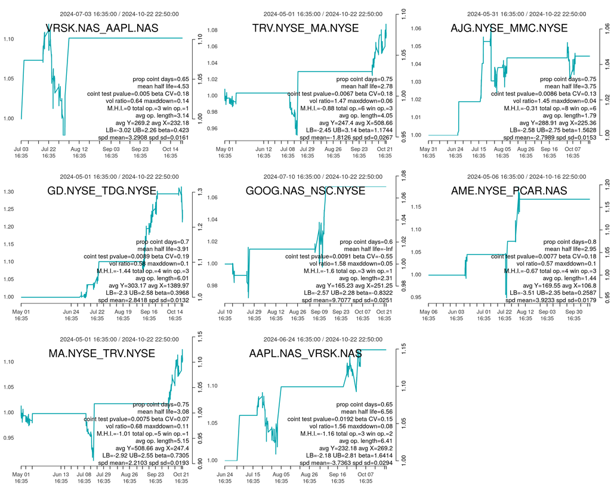

## `VRSK.NAS_AAPL.NAS`

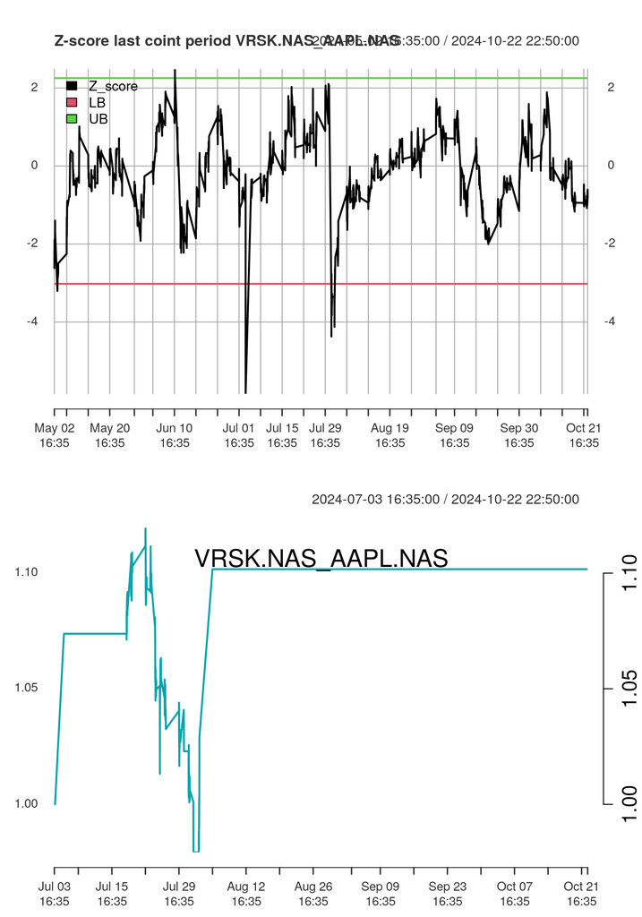

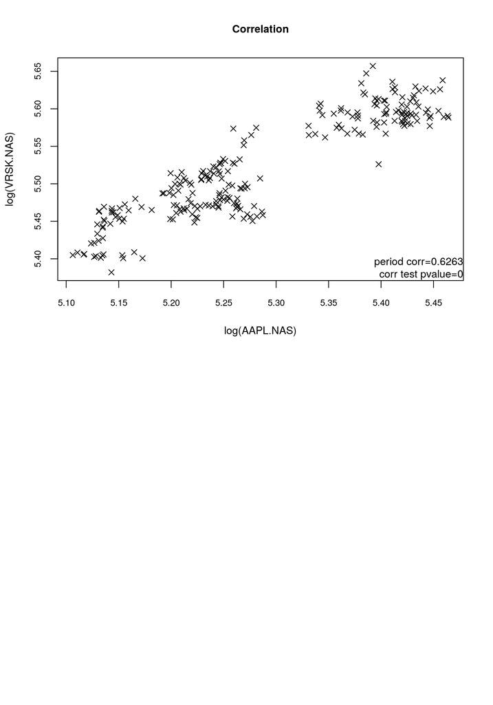

## `TRV.NYSE_MA.NYSE`

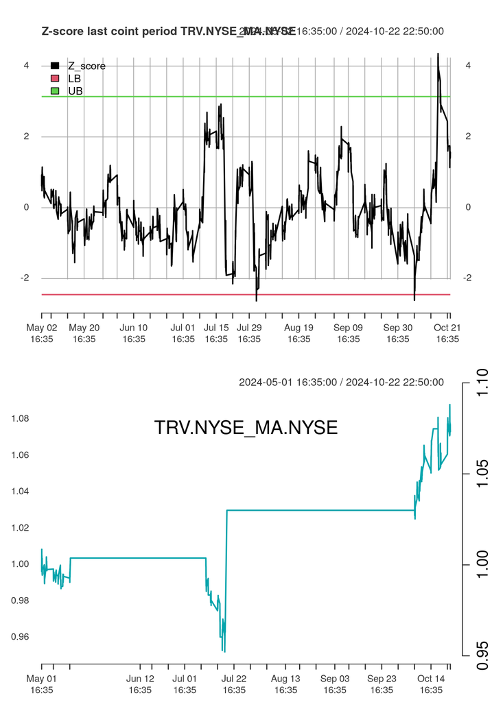

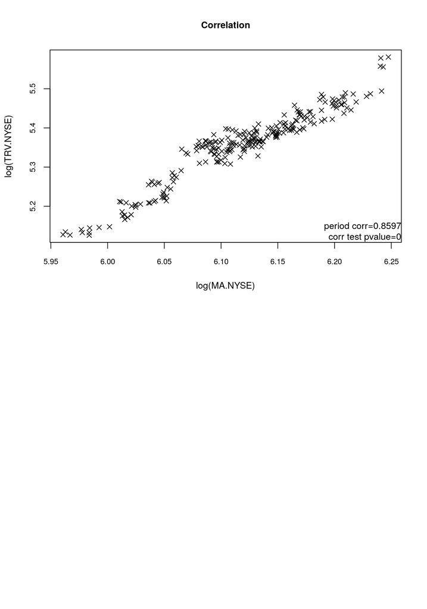

## `AJG.NYSE_MMC.NYSE`

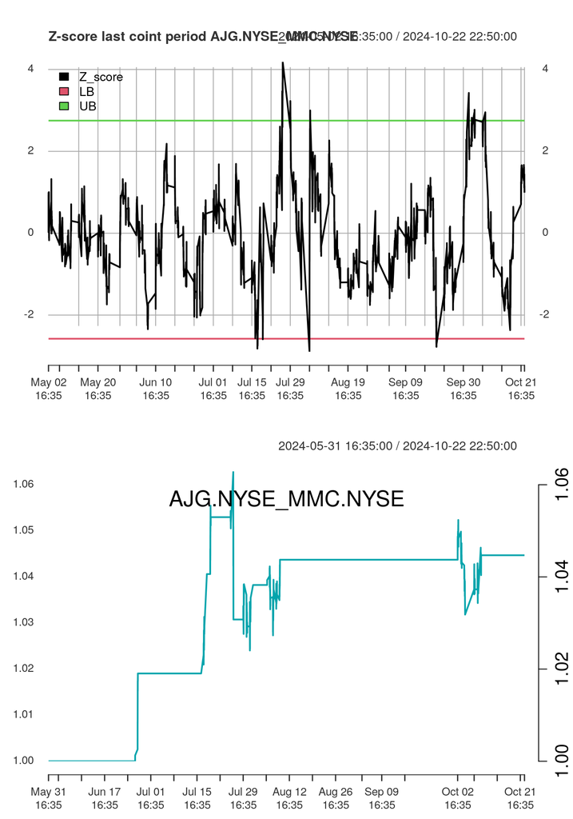

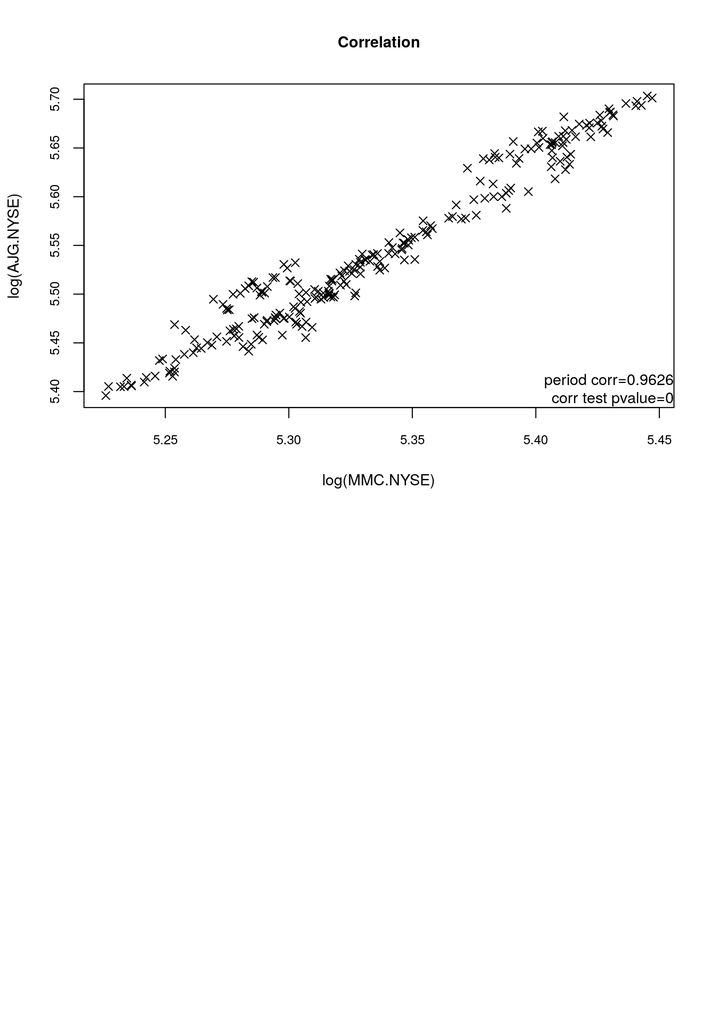

## `GD.NYSE_TDG.NYSE`

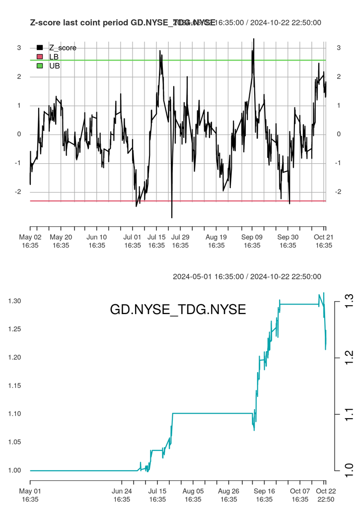

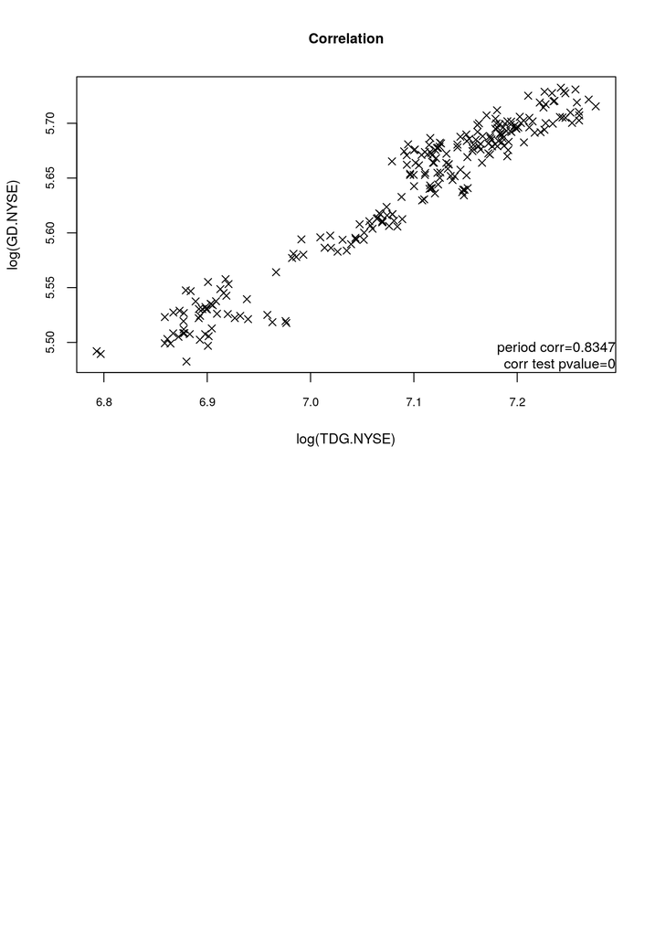

## `GOOG.NAS_NSC.NYSE`

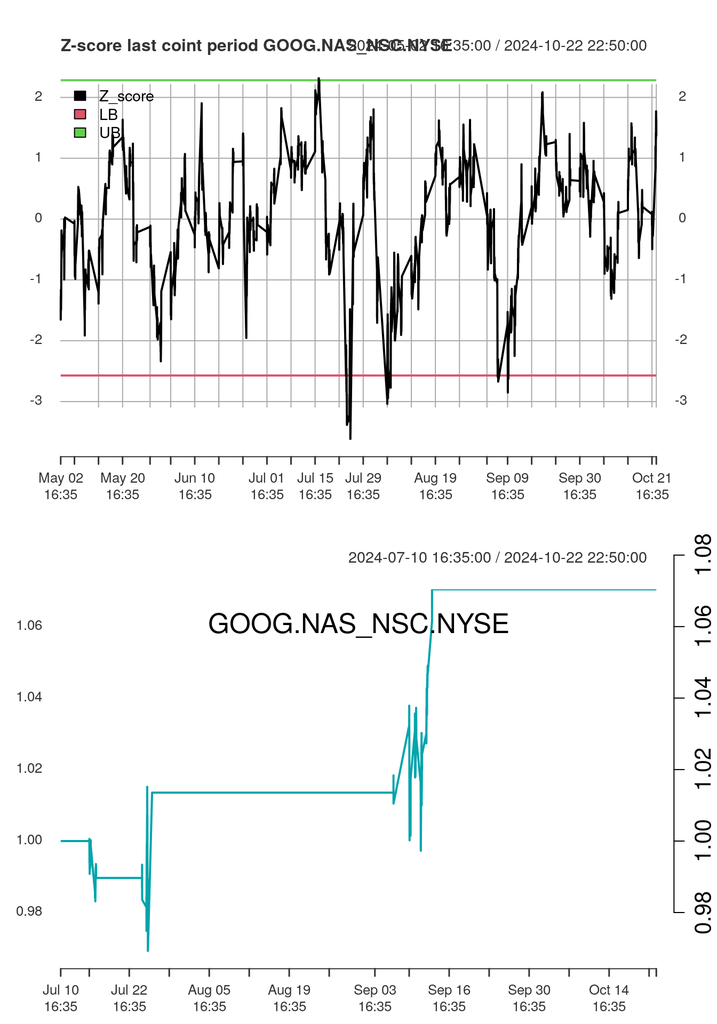

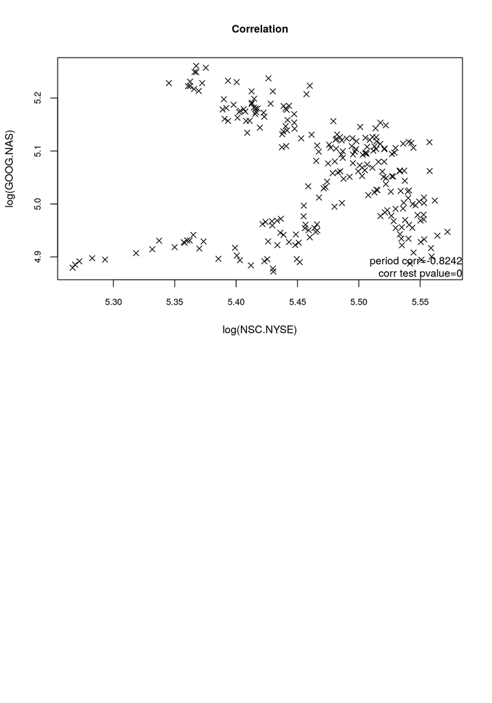

## `AME.NYSE_PCAR.NAS`

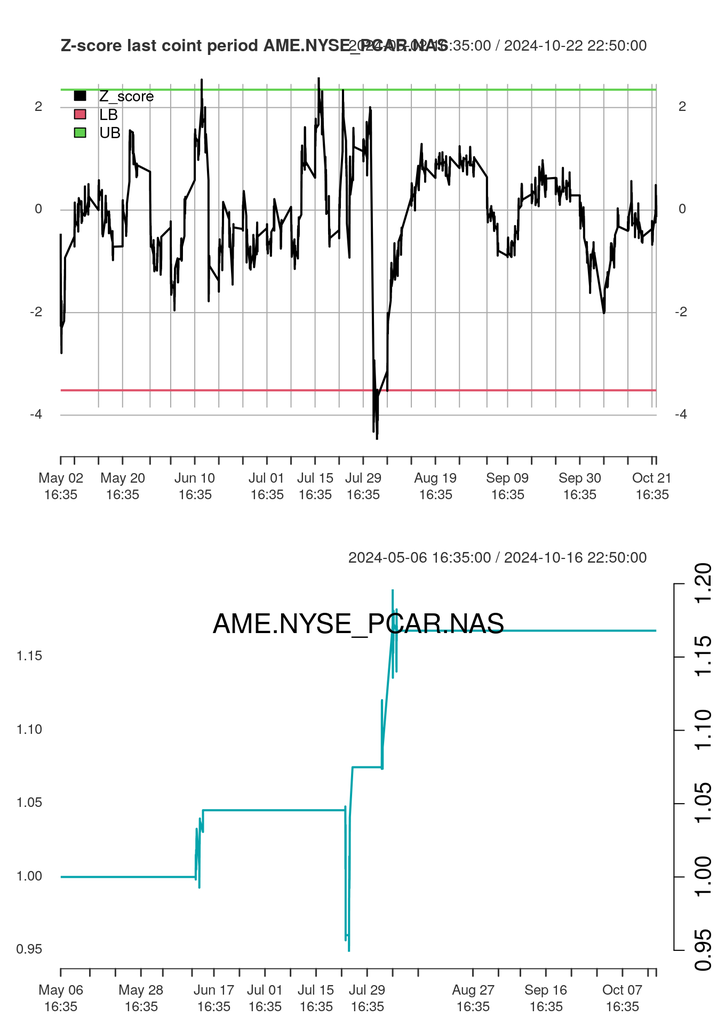

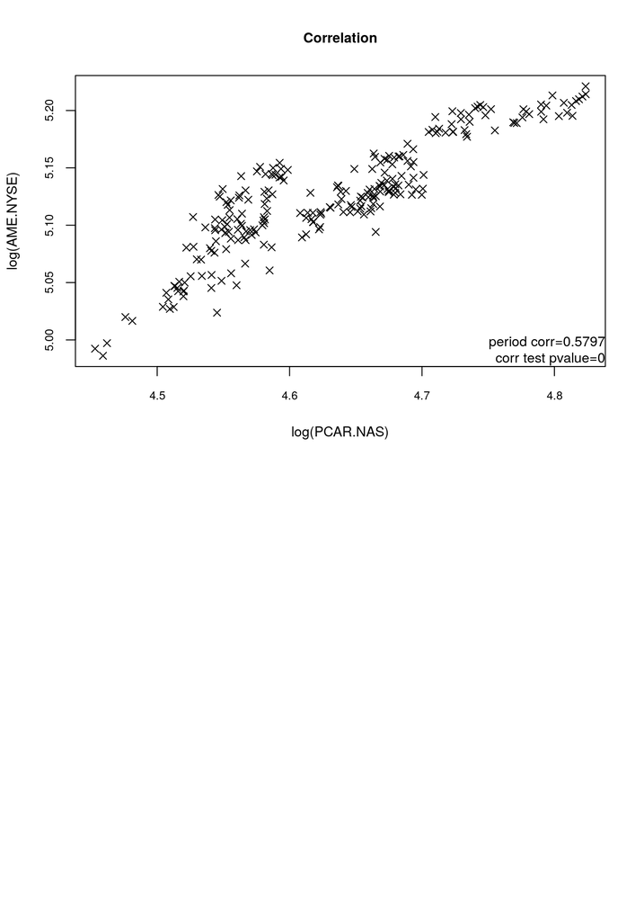

## `MA.NYSE_TRV.NYSE`

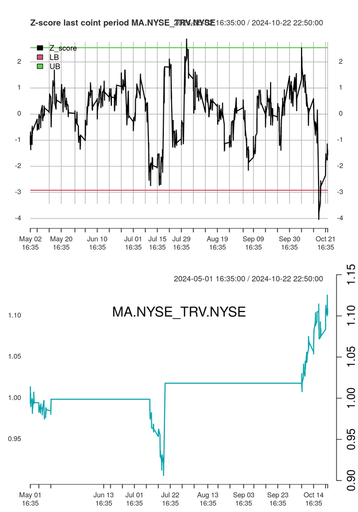

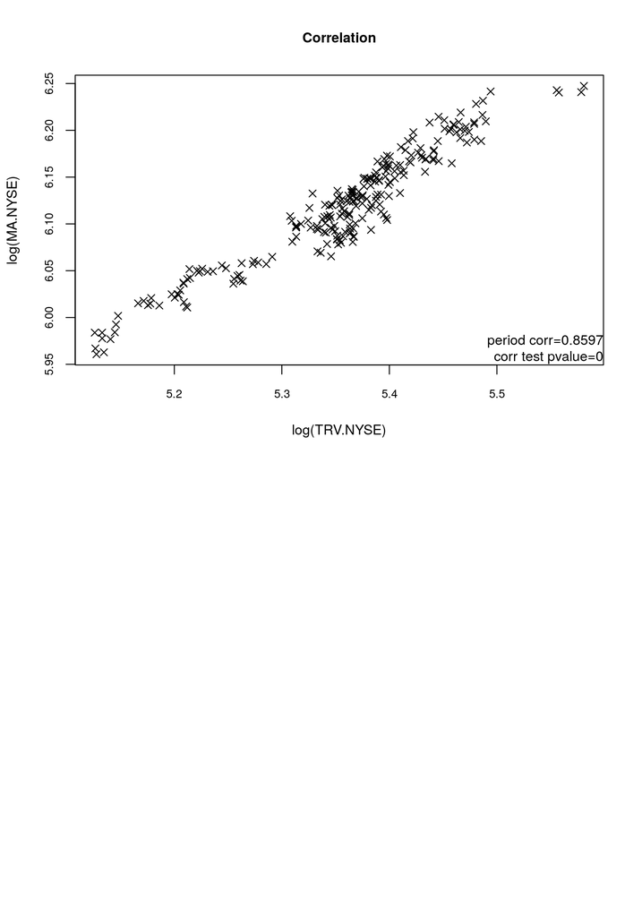

## `AAPL.NAS_VRSK.NAS`

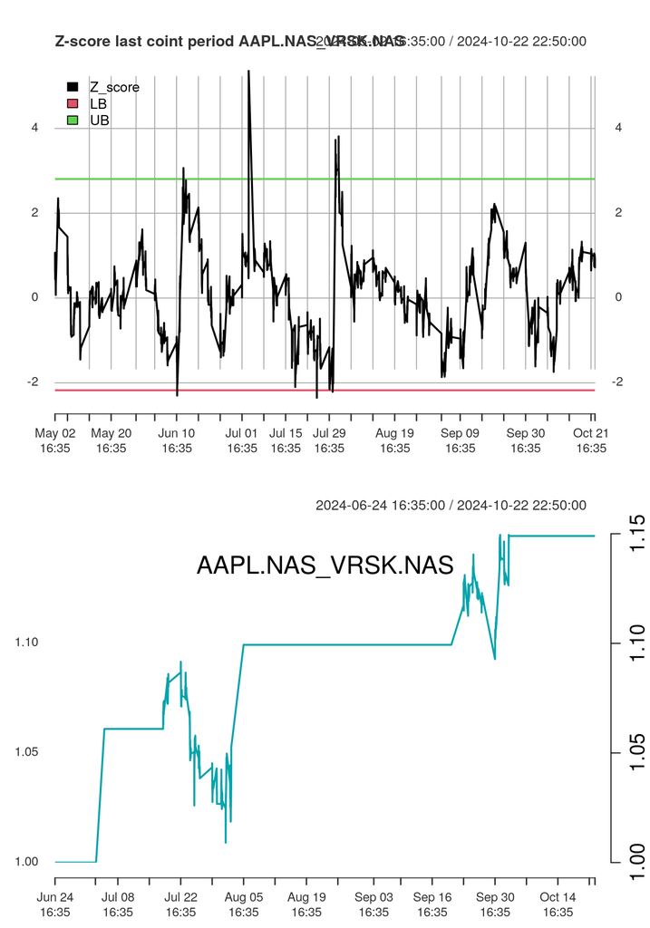

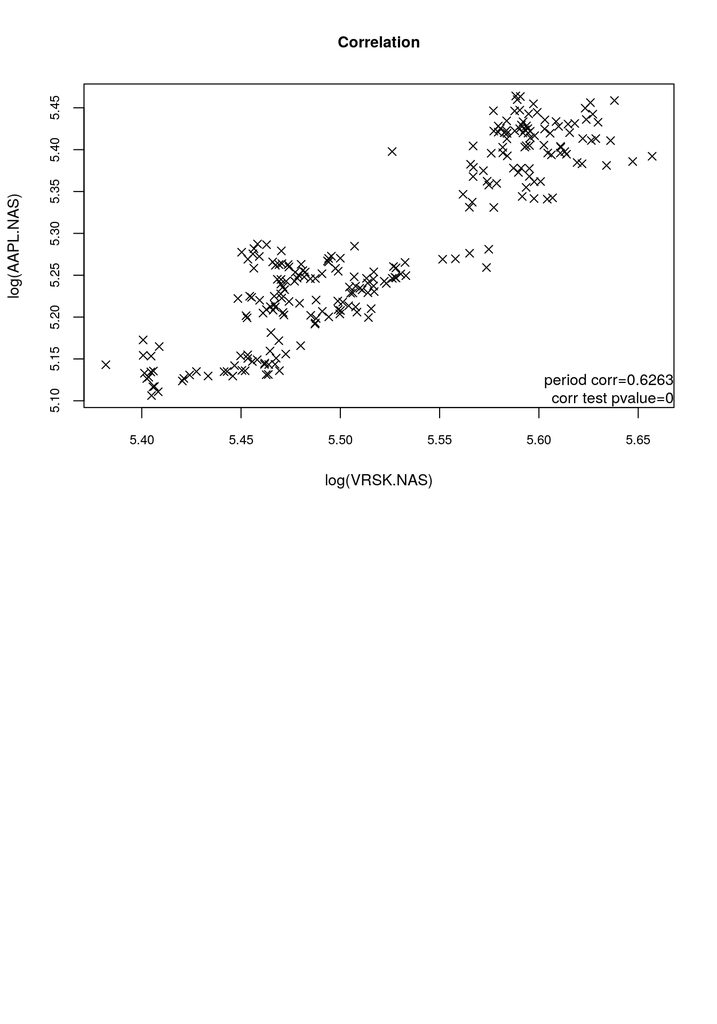

## Lista de termos e parâmetros

### `prop_coint_periods` - Proporção de períodos cointegrados.

> **Para quê serve?** - Verificar se a cointegração do par em análise é persistente ao longo do tempo.

> **Comportamento desejado** - quanto mais próximo de 1, mais persistente é a cointegracao ao longo do tempo.

### `mean_half_life` - Média (em dias) da meia-vida do par considerando todos os períodos em que o par estava cointegrado.

> **Para quê serve?** - Verificar quanto tempo o z-score do par em análise leva para retornar metade do caminho após afastar-se da média zero do z-score.

> **Comportamento desejado** - quanto mais baixo, menor tende a ser o tempo médio de operação naquele par, reduzindo-se assim custos de aluguel, etc.

### `coint_test_pvalue` - p-valor do teste de cointegracao referente a D-1.

> **Para quê serve?** - Verificar a probabilidade de observar um valor tão extremo quanto o observado nos dados do par em análise, quando consideramos a hipótese nula de que os papéis não seriam cointegrados (existência de raiz unitária na série temporal).

> **Comportamento desejado** - quanto menor o p-valor, maior é o indício de que os pares sejam realmente cointegrados .

### `beta CV` - Coeficiente de variação do Beta da regressão.

> **Para quê serve?** - Verificar se a relação entre ativo X e ativo Y é relativamente estável ao longo do tempo, ou seja, se apresenta alta ou baixa dispersão relativa. É um indicador de variabilidade relativa dos dados, onde dividimos o desvio padrão do beta observado durante os períodos cointegrados pela média dos valores nesses períodos. É expresso em percentual.

> **Comportamento desejado** - quanto menor o valor do coeficiente de variação, mais estável é a relacao linear entre ativo X e ativo Y.

### `vol_ratio` - Razão de volatilidades

> **Para quê serve?** - Verificar se a volatilidade dos dois ativos é parecida. O cálculo é feito dividindo-se o desvio padrão de um ativo pelo outro. Quanto mais próximo de 1, maior a similaridade entre eles. Este indicador é importante para evitar desbalanceamentos financeiros após montarmos uma operação. Grandes discrepâncias em termos de volatilidade podem fazer que a operação fique negativa financeiramente mesmo quando o z-score caminha na direção esperada.

> **Comportamento desejado** - quanto mais próximo de 1, mais similar é a estrutura de volatilidade dos ativos e menor é o risco de descasamento entre resultado financeiro e z-score ao longo da operação.

### `maxddown` - Drawdown máximo

> **Para quê serve?** - É um indicador de risco da operação no par. O máximo drawdown mostra em termos percentuais a maior distância entre máximos e mínimos no gráfico de profit & loss acumulado.

> **Comportamento desejado** - em tese, quanto menor o máximo drawdown, menor o risco operacional do par em análise.

### `M.H.I.` - Indicador proprietário da Quantl

> **Para quê serve?** - É um indicador de risco propritário da Quantl.

> **Comportamento desejado** - em tese, quanto maior e mais positivo o `M.H.I.`, mais “suave” é a operação, ou seja, menos “calor” o investidor passa antes finalizar a operação com lucro.

### `total op.` - Total de operações no período analisado no gráfico

> **Para quê serve?** - Verificar quantas operações houve para o par em análise.

> **Comportamento desejado** - não há como dizer se um par com mais ou menos operações é preferível. Este dado deve ser analisado em conjunto com o número de operações vencedoras `win op.`

### `win op.` - Operações vencedoras do período analisado

> **Para quê serve?** - Verificar quantas operações vencedoras houve para o par em análise.

> **Comportamento desejado** - quanto maior o número de opera,ões vencedoras em relação ao total de operações, maior a chance sucesso em uma nova operação de reversão à média no par em análise.

### `mean op. length` - Duração média das operações (em dias)

> **Para quê serve?** - Verificar o quanto tempo em média as operações do par em análise duraram. Este parâmetro não deve ser confundido com o meia-vida do par.

> **Comportamento desejado** - em tese, ao compararmos dois ou mais pares, quanto menor a duração média das operações, melhor seria o par, uma vez que isso impacta nos custos operacionais, como custo de aluguel da ponta vendida.

### `beta` - Valor estimado para o dia D do coeficiente angular da regressão linear entre ativo Y e ativo X

> **Para quê serve?** - Realizar o balanceamento beta-neutral de lotes dos ativos para operação.

> **Comportamento desejado** - Recomenda-se buscar pares em que valor do beta esteja alinhado ao valor da razão de volatilidades `vol_ratio` para que a chance de descasamento entre resultado financeiro e z-score seja reduzida. Por exemplo, um beta igual a 0.8 significa 0.8 shares do ativo Y para cada share do ativo X. Isso indica que a “velocidade” dos preços de X é um pouco maior do que a de Y. Espera-se, portanto, que a `vol_ratio` de Y por X seja também um pouco menor que 1, já que há mais movimentação de preços em X do que em Y. Quanto mais próximo `beta` e `vol_ratio` forem de 1, menor a chance de distorções entre financeiro e z-score.

### `avg Y` - Preço médio do ativo Y no período analisado

> **Para quê serve?** - Comparar com o preço médio do ativo X e evitar operações em que haja um descasamento muito grande de preços entre os dois ativos. Ativos com preços muito discrepantes tendem a ter `vol_ratio` e `beta` muito longe de 1.

> **Comportamento desejado** - Recomenda-se buscar pares em que a média de precos de Y e de X sejam parecidas.

### `avg X` - Preço médio do ativo X no período analisado

> **Para quê serve?** - Comparar com o preço médio do ativo Y e evitar operações em que haja um descasamento muito grande de preços entre os dois ativos. Ativos com preços muito discrepantes tendem a ter `vol_ratio` e `beta` muito longe de 1.

> **Comportamento desejado** - Recomenda-se buscar pares em que a média de precos de Y e de X sejam parecidas.